# Before we get to buiding models and visualizing the data we need to see what kind of dataset this

# Make a bar plot to visusalize the distributions of targets

```python
target = train['target']
features = [c for c in train if c not in ['ID_code', 'target']]
```

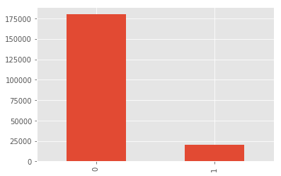

```python
train['target'].value_counts().plot.bar()
```

Just some more visualizations to see the distributions of the targets

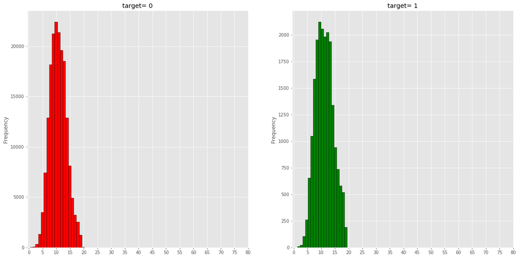

```python
f,ax=plt.subplots(1,2,figsize=(20,10))
train[train['target']==0].var_0.plot.hist(ax=ax[0],bins=20,edgecolor='black',color='red')
ax[0].set_title('target= 0')
x1=list(range(0,85,5))
ax[0].set_xticks(x1)
train[train['target']==1].var_0.plot.hist(ax=ax[1],color='green',bins=20,edgecolor='black')
ax[1].set_title('target= 1')
x2=list(range(0,85,5))
ax[1].set_xticks(x2)
plt.show()
```

Here we plot two graphs that signify the same result,we are trying to show the division of the targets into various categories.

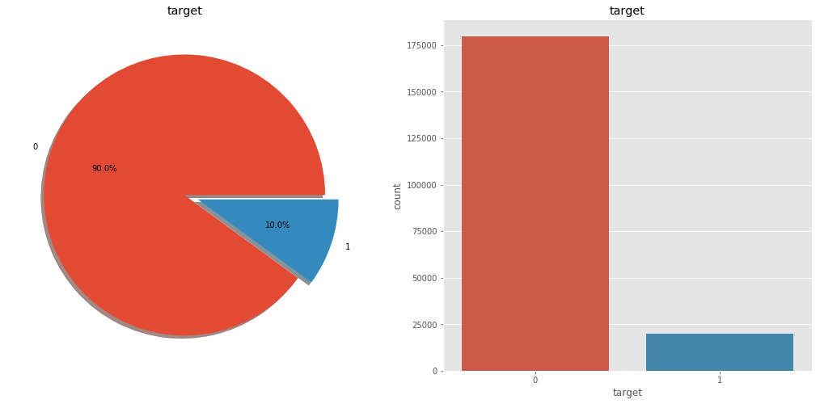

```python
f,ax=plt.subplots(1,2,figsize=(18,8))
train['target'].value_counts().plot.pie(explode=[0,0.1],autopct='%1.1f%%',ax=ax[0],shadow=True)
ax[0].set_title('target')
ax[0].set_ylabel('')
sns.countplot('target',data=train,ax=ax[1])
ax[1].set_title('target')
plt.show()
```

now we check the following things

```python
def check_balance(df,target):
    check=[]
    print('size of data is:',df.shape[0] )
    for i in [0,1]:
        print('for target  {} ='.format(i))
        print(df[target].value_counts()[i]/df.shape[0]*100,'%')
check_balance(train,'target')
```

```
size of data is: 200000
for target  0 =
89.95100000000001 %
for target  1 =
10.049 %
```

We will also check for skewness and kurtosis here

```python
print("Skewness: %f" % train['target'].skew())
print("Kurtosis: %f" % train['target'].kurt())
```

```
Skewness: 2.657642
Kurtosis: 5.063112
```

Before we get to the more difficult models we will just try the simplest logistic regression

```python
kfolds = StratifiedKFold(n_splits=10, random_state=1).split(train.values, target.values)

oof = np.zeros(len(train))
predictions = np.zeros(len(test))

for k, (trn_idx, val_idx) in enumerate(kfolds):
    print('Fold: {}'.format(k))

    clf = LogisticRegression(solver='lbfgs', max_iter=1500, C=10)
    clf.fit(train.iloc[trn_idx][features], target[trn_idx])
    oof[val_idx] = clf.predict_proba(train.iloc[val_idx][features])[:, 1]
    predictions += clf.predict_proba(test[features])[:, 1]


predictions /= 10

print('CV score: {}'.format(roc_auc_score(target.values, oof)))
```

```
Fold: 0
Fold: 1
Fold: 2
Fold: 3
Fold: 4
Fold: 5
Fold: 6
Fold: 7
Fold: 8
Fold: 9
CV score: 0.859088763576557
```

```python
kfolds = StratifiedKFold(n_splits=10, random_state=1).split(train.values, target.values)

oof = np.zeros(len(train))
predictions = np.zeros(len(test))
from sklearn.naive_bayes import GaussianNB
from sklearn.metrics import roc_curve, auc
nb_clf = GaussianNB()
for k, (trn_idx, val_idx) in enumerate(kfolds):
    print('Fold: {}'.format(k))
    nb_clf.fit(train.iloc[trn_idx][features], target[trn_idx])
    oof[val_idx] = nb_clf.predict_proba(train.iloc[val_idx][features])[:, 1]
    predictions += nb_clf.predict_proba(test[features])[:, 1]


predictions /= 10

print('CV score: {}'.format(roc_auc_score(target.values, oof)))
```

```
Fold: 0
Fold: 1
Fold: 2
Fold: 3
Fold: 4
Fold: 5
Fold: 6
Fold: 7
Fold: 8
Fold: 9
CV score: 0.8884322742896391
```

### Before anything we will try a very simple neural network model

```python
df_train = pd.read_csv('train.csv', index_col=0)
y_train = df_train.pop('target')


len_train = len(df_train)
df_test = pd.read_csv('test.csv', index_col=0)
df_all = pd.concat((df_train, df_test), sort=False)
prev_cols = df_all.columns


scaler = StandardScaler()
df_all[prev_cols] = scaler.fit_transform(df_all[prev_cols])
df_train = df_all[0:len_train]
df_test = df_all[len_train:]
```

```python
def augment_train(df_train, y_train):
    t0 = df_train[y_train == 0].copy()
    t1 = df_train[y_train == 1].copy()
    i = 0
    N = 3
    for I in range(0):  # augment data into 2x
        for col in df_train.columns:
            i = i + 1000
            np.random.seed(i)
            np.random.shuffle(t0[col].values)
            np.random.shuffle(t1[col].values)
        df_train = pd.concat([df_train, t0.copy()])
        df_train = pd.concat([df_train, t1.copy()])
        y_train = pd.concat([y_train, pd.Series([0] * t0.shape[0]), pd.Series([1] * t1.shape[0])])
        return df_train, y_train
```

```python
features = [c for c in df_train.columns if c not in ["ID_code","target"]]
def detect_test(test_df):
    df_test=test_df.values
    unique_count = np.zeros_like(df_test)
    for feature in tqdm(range(df_test.shape[1])):
        _, index_, count_ = np.unique(df_test[:, feature], return_counts=True, return_index=True)
        unique_count[index_[count_ == 1], feature] += 1


    real_samples_indexes = np.argwhere(np.sum(unique_count, axis=1) > 0)[:, 0]
    synthetic_samples_indexes = np.argwhere(np.sum(unique_count, axis=1) == 0)[:, 0]
    return real_samples_indexes,synthetic_samples_indexes
def generate_fe(trn, tst):

    real,syn = detect_test(df_test[features])
    al = pd.concat([trn,tst,df_test.iloc[real]],axis=0)
    trn_fe = pd.DataFrame()
    tst_fe = pd.DataFrame()
    for c in features:
        trn[c+"_test"]=trn[c].map(al[c].value_counts())
        trn[c+"_multi"] = trn[c+"_test"]*trn[c]

        trn_fe[c] = trn[c]
        trn_fe[c+"_test"] = trn[c+"_test"]
        trn_fe[c+"_muti"] = trn[c+"_multi"]

        tst[c+"_test"]=tst[c].map(al[c].value_counts())

        tst_fe[c] = tst[c]
        tst[c+"_multi"] = tst[c+"_test"]*tst[c]

        tst_fe[c+"_test"] = tst[c+"_test"]
        tst_fe[c+"_muti"] = tst[c+"_multi"]

    return trn_fe, tst_fe
def generate_fe_test(tst):
    re,sy =  detect_test(tst[features])
    al = pd.concat([df_train,df_test.iloc[re]],axis=0)
    tst_fe = pd.DataFrame()
    for c in features:
        tst[c+"_test"]=tst[c].map(al[c].value_counts())

        tst_fe[c] = tst[c]
        tst[c+"_multi"] = tst[c+"_test"]*tst[c]

        tst_fe[c+"_test"] = tst[c+"_test"]
        tst_fe[c+"_muti"] = tst[c+"_multi"]

    return tst_fe
test_fe = generate_fe_test(df_test[features])
def auc(y_true, y_pred):
    return tf.py_func(roc_auc_score, (y_true, y_pred), tf.double)
def _Model():
    inp = Input(shape=(200,3))
    d1 = Dense(32,activation='relu')(inp)
    d1 = BatchNormalization()(d1)
    d1 = Dense(8,activation="relu")(d1)
    d1 = BatchNormalization()(d1)
    d4 = Flatten()(d1)
    preds = Dense(1, activation="sigmoid")(d4)
    model = Model(inputs=inp, outputs=preds)
    adam = optimizers.Adam(lr=0.009)
    model.compile(optimizer=adam, loss=K.binary_crossentropy,metrics=["acc"])
    model.summary()
    return model
# LOGGER
class Logger(callbacks.Callback):
    def __init__(self, out_path='./', patience=30, lr_patience=3, out_fn='', log_fn=''):
        self.auc = 0
        self.path = out_path
        self.fn = out_fn
        self.patience = patience
        self.lr_patience = lr_patience
        self.no_improve = 0
        self.no_improve_lr = 0

    def on_train_begin(self, logs={}):
        return

    def on_train_end(self, logs={}):
        return

    def on_epoch_begin(self, epoch, logs={}):
        return

    def on_batch_begin(self, batch, logs={}):
        return

    def on_batch_end(self, batch, logs={}):
        return

    def on_epoch_end(self, epoch, logs={}):
        cv_pred = self.model.predict(self.validation_data[0], batch_size=1024)
        cv_true = self.validation_data[1]
        auc_val = roc_auc_score(cv_true, cv_pred)
        if self.auc < auc_val:
            self.no_improve = 0
            self.no_improve_lr = 0
            print("Epoch %s - best AUC: %s" % (epoch, round(auc_val, 4)))
            self.auc = auc_val
            self.model.save(self.path + self.fn, overwrite=True)
        else:
            self.no_improve += 1
            self.no_improve_lr += 1
            print("Epoch %s - current AUC: %s" % (epoch, round(auc_val, 4)))
            if self.no_improve >= self.patience:
                self.model.stop_training = True
            if self.no_improve_lr >= self.lr_patience:
                lr = float(K.get_value(self.model.optimizer.lr))
                K.set_value(self.model.optimizer.lr, 0.75*lr)
                print("Setting lr to {}".format(0.75*lr))
                self.no_improve_lr = 0

        return

preds = []
c = 0
oof_preds = np.zeros((len(df_train), 1))
cv = StratifiedKFold(n_splits=2,shuffle=True, random_state=3263)
for train, valid in cv.split(df_train, y_train):
    print("VAL %s" % c)
    trn = df_train.iloc[train]
    tst = df_train.iloc[valid]
    trn, tst = generate_fe(trn, tst)
    X_train = np.reshape(trn.values, (-1,200,3))
    y_train_ = y_train.iloc[train].values
    X_valid = np.reshape(tst.values, (-1,200,3))
    y_valid = y_train.iloc[valid].values
    model = _Model()
    logger = Logger(patience=30, out_path='./', out_fn='cv_{}.h5'.format(c))
    model.fit(X_train, y_train_, validation_data=(X_valid, y_valid), epochs=30, verbose=2, batch_size=512,
              callbacks=[logger])
    model.load_weights('cv_{}.h5'.format(c))
    fe = [c for c in test_fe.columns if c not in ["ID_code","target"]]
    X_test = np.reshape(test_fe[fe].values, (200000, 200, 3))
    curr_preds = model.predict(X_test, batch_size=2048)
    oof_preds[valid] = model.predict(X_valid)
    preds.append(curr_preds)
    c += 1
pd.DataFrame(oof_preds).to_csv("NN_oof_preds.csv", index = False)
auc = roc_auc_score(y_train, oof_preds)
print("CV_AUC: {}".format(auc))
```

```
VAL 0
```

```
_________________________________________________________________
Layer (type)                 Output Shape              Param #
=================================================================
input_2 (InputLayer)         (None, 200, 3)            0
_________________________________________________________________
dense_4 (Dense)              (None, 200, 32)           128
_________________________________________________________________
batch_normalization_3 (Batch (None, 200, 32)           128
_________________________________________________________________
dense_5 (Dense)              (None, 200, 8)            264
_________________________________________________________________
batch_normalization_4 (Batch (None, 200, 8)            32
_________________________________________________________________
flatten_2 (Flatten)          (None, 1600)              0
_________________________________________________________________
dense_6 (Dense)              (None, 1)                 1601
=================================================================
Total params: 2,153
Trainable params: 2,073
Non-trainable params: 80
_________________________________________________________________
Train on 100000 samples, validate on 100000 samples
 - 6s - loss: 0.2237 - acc: 0.9179 - val_loss: 0.5059 - val_acc: 0.9012
Epoch 0 - best AUC: 0.9004
 - 6s - loss: 0.1960 - acc: 0.9281 - val_loss: 0.3175 - val_acc: 0.9098
Epoch 1 - best AUC: 0.9101
 - 6s - loss: 0.1877 - acc: 0.9306 - val_loss: 0.2574 - val_acc: 0.9162
Epoch 2 - best AUC: 0.9107
 - 6s - loss: 0.1845 - acc: 0.9325 - val_loss: 0.2376 - val_acc: 0.9188
Epoch 3 - best AUC: 0.9142
 - 6s - loss: 0.1820 - acc: 0.9333 - val_loss: 0.3172 - val_acc: 0.9109
Epoch 4 - best AUC: 0.9155
 - 6s - loss: 0.1815 - acc: 0.9332 - val_loss: 0.2591 - val_acc: 0.9167
Epoch 5 - best AUC: 0.9189
 - 6s - loss: 0.1801 - acc: 0.9338 - val_loss: 0.1874 - val_acc: 0.9293
Epoch 6 - best AUC: 0.9192
 - 6s - loss: 0.1790 - acc: 0.9345 - val_loss: 0.1860 - val_acc: 0.9316
Epoch 7 - current AUC: 0.919
 - 6s - loss: 0.1788 - acc: 0.9343 - val_loss: 0.2143 - val_acc: 0.9185
Epoch 8 - best AUC: 0.9203
```

[output cut: 31 more lines]

```
Epoch 23 - current AUC: 0.9206
Setting lr to 0.003796875011175871
 - 6s - loss: 0.1706 - acc: 0.9375 - val_loss: 0.1935 - val_acc: 0.9262
Epoch 24 - best AUC: 0.9211
 - 6s - loss: 0.1707 - acc: 0.9372 - val_loss: 0.1917 - val_acc: 0.9282
Epoch 25 - best AUC: 0.9211
 - 6s - loss: 0.1706 - acc: 0.9371 - val_loss: 0.1804 - val_acc: 0.9334
Epoch 26 - current AUC: 0.921
 - 6s - loss: 0.1707 - acc: 0.9373 - val_loss: 0.1819 - val_acc: 0.9316
Epoch 27 - best AUC: 0.9212
 - 6s - loss: 0.1712 - acc: 0.9372 - val_loss: 0.1848 - val_acc: 0.9323
Epoch 28 - current AUC: 0.9206
 - 6s - loss: 0.1709 - acc: 0.9367 - val_loss: 0.1819 - val_acc: 0.9318
Epoch 29 - current AUC: 0.9211
VAL 1
```

```
_________________________________________________________________
Layer (type)                 Output Shape              Param #
=================================================================
input_3 (InputLayer)         (None, 200, 3)            0
_________________________________________________________________
dense_7 (Dense)              (None, 200, 32)           128
_________________________________________________________________
batch_normalization_5 (Batch (None, 200, 32)           128
_________________________________________________________________
dense_8 (Dense)              (None, 200, 8)            264
_________________________________________________________________
batch_normalization_6 (Batch (None, 200, 8)            32
_________________________________________________________________
flatten_3 (Flatten)          (None, 1600)              0
_________________________________________________________________
dense_9 (Dense)              (None, 1)                 1601
=================================================================
Total params: 2,153
Trainable params: 2,073
Non-trainable params: 80
_________________________________________________________________
Train on 100000 samples, validate on 100000 samples
 - 7s - loss: 0.2172 - acc: 0.9209 - val_loss: 0.2318 - val_acc: 0.9173
Epoch 0 - best AUC: 0.8973
 - 6s - loss: 0.1890 - acc: 0.9296 - val_loss: 0.3706 - val_acc: 0.8393
Epoch 1 - best AUC: 0.9073
 - 6s - loss: 0.1870 - acc: 0.9307 - val_loss: 0.2869 - val_acc: 0.8826
Epoch 2 - best AUC: 0.9128
 - 6s - loss: 0.1843 - acc: 0.9309 - val_loss: 0.3589 - val_acc: 0.8446
Epoch 3 - current AUC: 0.9096
 - 6s - loss: 0.1816 - acc: 0.9320 - val_loss: 0.2000 - val_acc: 0.9279
Epoch 4 - best AUC: 0.9129
 - 6s - loss: 0.1806 - acc: 0.9319 - val_loss: 0.1852 - val_acc: 0.9319
Epoch 5 - best AUC: 0.9143
 - 6s - loss: 0.1796 - acc: 0.9327 - val_loss: 0.2071 - val_acc: 0.9275
Epoch 6 - best AUC: 0.915
 - 6s - loss: 0.1779 - acc: 0.9337 - val_loss: 0.1915 - val_acc: 0.9311
Epoch 7 - current AUC: 0.913
 - 6s - loss: 0.1793 - acc: 0.9331 - val_loss: 0.2805 - val_acc: 0.9146
Epoch 8 - current AUC: 0.9145
```

[output cut: 8 more lines]

```
 - 6s - loss: 0.1757 - acc: 0.9344 - val_loss: 0.2496 - val_acc: 0.9189
Epoch 13 - current AUC: 0.9149
 - 6s - loss: 0.1744 - acc: 0.9343 - val_loss: 0.1881 - val_acc: 0.9322
Epoch 14 - best AUC: 0.916
 - 6s - loss: 0.1752 - acc: 0.9343 - val_loss: 0.1847 - val_acc: 0.9323
Epoch 15 - best AUC: 0.9163
 - 6s - loss: 0.1764 - acc: 0.9336 - val_loss: 0.2355 - val_acc: 0.9226
Epoch 16 - current AUC: 0.9157
 - 6s - loss: 0.1747 - acc: 0.9348 - val_loss: 0.1898 - val_acc: 0.9304
Epoch 17 - current AUC: 0.916
 - 6s - loss: 0.1746 - acc: 0.9347 - val_loss: 0.1843 - val_acc: 0.9330
Epoch 18 - current AUC: 0.9152
Setting lr to 0.006749999709427357
 - 6s - loss: 0.1722 - acc: 0.9355 - val_loss: 0.1840 - val_acc: 0.9328
Epoch 19 - current AUC: 0.9162
```

[output not shown]

```python
# SAVE DATA
preds = np.asarray(preds)
preds = preds.reshape((1, 200000))
preds_final = np.mean(preds.T, axis=1)
submission = pd.read_csv('sample_submission.csv')
submission['target'] = preds_final
submission.to_csv('submission.csv', index=False)
```